# Practical Machine Learning Project

## Introduction

For this project, we were given information from accelerometers on the belt, forearm, arm, and dumbbell of 6 participants. These participants were to perform barbell lifts correctly and incorrectly 5 different ways. The goal of the analysis was to determine which of those 5 ways the participant was performing the task using the information given by the accelerometers.

## Loading the Data and Necessary Packages

```r
download.file("http://d396qusza40orc.cloudfront.net/predmachlearn/pml-training.csv",
              destfile = "training.csv")
download.file("http://d396qusza40orc.cloudfront.net/predmachlearn/pml-testing.csv",
              destfile = 'testing.csv')
traindata <- read.csv("training.csv")
testdata <- read.csv('testing.csv')
library(caret)
library(rattle)
library(rpart.plot)
```

## Processing the Data

The first step in the process was to partition the data into a training set and a testing set. The training set is the data that was used to train the models on. Once the best method to use was determined, that method was applied to the testing set.

```r
inTrain <- createDataPartition(y=traindata$classe, p = 0.7, list = FALSE)
training <- traindata[inTrain,]
testing <- traindata[-inTrain,]
dim(training)
```

```
## [1] 13737   160
```

```r
dim(testing)
```

```
## [1] 5885  160
```

The dimensions show that there were 160 columns (159 variables to consider). Before proceeding, I took a look at the data. There were numerous columns that would not be applicable for the analysis. For example, the first 7 columns were related to things such as participant name, number, date, etc. These variables would not be applicable to the question trying to be answered. Next, I noticed that many of the columns were mostly unfilled with no data or had NA values. These columns were also taken out of the data set. This was the final data set that was worked with. New data sets were created using only the applicable columns for both the training and testing data.

```r
training <- training[,c(8:11,37:48, 60:68, 84:86, 102, 113:124, 140, 151:160)]
testing <- testing[,c(8:11,37:48, 60:68, 84:86, 102, 113:124, 140, 151:160)]
dim(training)
```

```
## [1] 13737    52
```

```r
dim(testing)
```

```
## [1] 5885   52
```

## Creating the models

First, a classification tree was attempted. The data was preprocessed and used 3-fold cross validation.

```r
set.seed(4321)
modelFitRPART <- train(classe ~ ., data = training, preProcess = c('center', 'scale'),
                   trControl = trainControl(method = 'cv', number = 3), method = 'rpart')
print(modelFitRPART)
```

```
## CART
##
## 13737 samples
##    51 predictor
##     5 classes: 'A', 'B', 'C', 'D', 'E'
##
## Pre-processing: centered, scaled
## Resampling: Cross-Validated (3 fold)
##
## Summary of sample sizes: 9158, 9158, 9158
##
## Resampling results across tuning parameters:
##
##   cp          Accuracy   Kappa       Accuracy SD  Kappa SD
##   0.03377073  0.5060785  0.35440258  0.00905807   0.01157618
##   0.05933611  0.4508262  0.26677583  0.07498143   0.12506895
##   0.11667175  0.3109849  0.04079838  0.04614767   0.07066486
##
## Accuracy was used to select the optimal model using  the largest value.
## The final value used for the model was cp = 0.03377073.
```

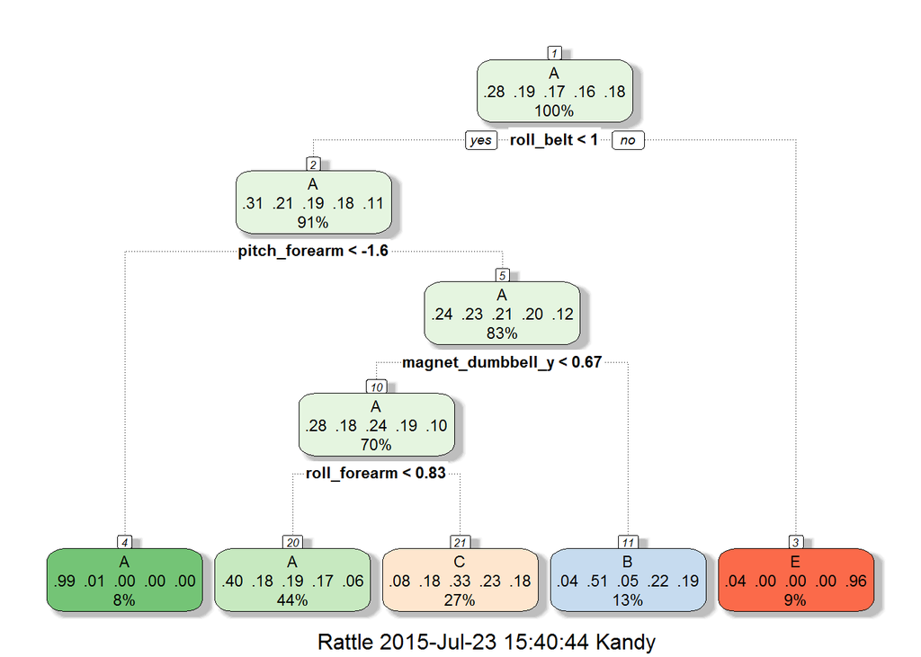

```r
fancyRpartPlot(modelFitRPART$finalModel)
```

```r
confusionMatrix(training$classe, predict(modelFitRPART, training))
```

```
## Confusion Matrix and Statistics
##
##           Reference
## Prediction    A    B    C    D    E
##          A 3524   61  276    0   45
##          B 1115  884  659    0    0
##          C 1114   79 1203    0    0
##          D 1016  386  850    0    0
##          E  335  331  667    0 1192
##
## Overall Statistics
##
##                Accuracy : 0.4952
##                  95% CI : (0.4868, 0.5036)
##     No Information Rate : 0.5171
##     P-Value [Acc > NIR] : 1
##
##                   Kappa : 0.3406
##  Mcnemar's Test P-Value : NA
##
## Statistics by Class:
##
##                      Class: A Class: B Class: C Class: D Class: E
## Sensitivity            0.4961  0.50775  0.32914       NA  0.96362
## Specificity            0.9424  0.85212  0.88167   0.8361  0.89336
## Pos Pred Value         0.9022  0.33258  0.50209       NA  0.47208
## Neg Pred Value         0.6358  0.92265  0.78379       NA  0.99599
## Prevalence             0.5171  0.12674  0.26607   0.0000  0.09005
## Detection Rate         0.2565  0.06435  0.08757   0.0000  0.08677
## Detection Prevalence   0.2843  0.19349  0.17442   0.1639  0.18381
## Balanced Accuracy      0.7192  0.67994  0.60540       NA  0.92849
```

This resulted in only a 49% accuracy which was a bit disappointing. It is also concerning that there is no path on the chart that will lead to category D.

Next, a random forrest method was attempted. The data was preprocessed and used 3-fold cross validation.

```r
set.seed(4321)
modelFitRF <- train(classe ~ ., data = training, preProcess = c('center', 'scale'),
                    trControl = trainControl(method = 'cv', number = 3), method = 'rf')
print(modelFitRF)
```

```
## Random Forest
##
## 13737 samples
##    51 predictor
##     5 classes: 'A', 'B', 'C', 'D', 'E'
##
## Pre-processing: centered, scaled
## Resampling: Cross-Validated (3 fold)
##
## Summary of sample sizes: 9158, 9158, 9158
##
## Resampling results across tuning parameters:
##
##   mtry  Accuracy   Kappa      Accuracy SD  Kappa SD
##    2    0.9903909  0.9878436  0.001903865  0.002408922
##   26    0.9884982  0.9854487  0.001454101  0.001840790
##   51    0.9809274  0.9758662  0.003847189  0.004873841
##
## Accuracy was used to select the optimal model using  the largest value.
## The final value used for the model was mtry = 2.
```

```r
confusionMatrix(training$classe, predict(modelFitRF, training))
```

```
## Confusion Matrix and Statistics
##
##           Reference
## Prediction    A    B    C    D    E
##          A 3906    0    0    0    0
##          B    0 2658    0    0    0
##          C    0    0 2396    0    0
##          D    0    0    0 2252    0
##          E    0    0    0    0 2525
##
## Overall Statistics
##
##                Accuracy : 1
##                  95% CI : (0.9997, 1)
##     No Information Rate : 0.2843
##     P-Value [Acc > NIR] : < 2.2e-16
##
##                   Kappa : 1
##  Mcnemar's Test P-Value : NA
##
## Statistics by Class:
##
##                      Class: A Class: B Class: C Class: D Class: E
## Sensitivity            1.0000   1.0000   1.0000   1.0000   1.0000
## Specificity            1.0000   1.0000   1.0000   1.0000   1.0000
## Pos Pred Value         1.0000   1.0000   1.0000   1.0000   1.0000
## Neg Pred Value         1.0000   1.0000   1.0000   1.0000   1.0000
## Prevalence             0.2843   0.1935   0.1744   0.1639   0.1838
## Detection Rate         0.2843   0.1935   0.1744   0.1639   0.1838
## Detection Prevalence   0.2843   0.1935   0.1744   0.1639   0.1838
## Balanced Accuracy      1.0000   1.0000   1.0000   1.0000   1.0000
```

The random forrest method acheived much better results. The accuracy for the training set was 100%. This was a little alarming because it was so high, but in the end, I decided to just go with it and see what happened with the testing data (hoping that I would not have to scrap everything I had done and start over).

```r
confusionMatrix(testing$classe, predict(modelFitRF, testing))
```

```
## Confusion Matrix and Statistics
##
##           Reference
## Prediction    A    B    C    D    E
##          A 1671    3    0    0    0
##          B    3 1132    4    0    0
##          C    0    8 1017    1    0
##          D    0    0   13  951    0
##          E    0    0    0   10 1072
##
## Overall Statistics
##
##                Accuracy : 0.9929
##                  95% CI : (0.9904, 0.9949)
##     No Information Rate : 0.2845
##     P-Value [Acc > NIR] : < 2.2e-16
##
##                   Kappa : 0.991
##  Mcnemar's Test P-Value : NA
##
## Statistics by Class:
##
##                      Class: A Class: B Class: C Class: D Class: E
## Sensitivity            0.9982   0.9904   0.9836   0.9886   1.0000
## Specificity            0.9993   0.9985   0.9981   0.9974   0.9979
## Pos Pred Value         0.9982   0.9939   0.9912   0.9865   0.9908
## Neg Pred Value         0.9993   0.9977   0.9965   0.9978   1.0000
## Prevalence             0.2845   0.1942   0.1757   0.1635   0.1822
## Detection Rate         0.2839   0.1924   0.1728   0.1616   0.1822
## Detection Prevalence   0.2845   0.1935   0.1743   0.1638   0.1839
## Balanced Accuracy      0.9987   0.9945   0.9909   0.9930   0.9990
```

## Conclusion

As a final step, I applied the prediction model to the testing data given to us which did result in full marks for the assignment:

```r
testdata <- testdata[,c(8:11,37:48, 60:68, 84:86, 102, 113:124, 140, 151:160)]
predict(modelFitRF, testdata)
```

```
##  [1] B A B A A E D B A A B C B A E E A B B B
## Levels: A B C D E
```